# 2018 March Madness Competition

# Model Building

To begin building predictive models, the required libraries need to be loaded into R. If the following libraries have not been installed, then each library would need to be downloaded first.

```r
library(tidyverse)
library(caret)
library(data.table)
library(Metrics)
library(knitr)
```

```r
TourneyDiff <- read_csv("TourneyDiff.csv")
```

To make sure that the dataframe was loaded in correctly, a quick peak can be taken by using the head() function. To see the entire dataframe, the view() function should be utilized. However, this is a relatively large dataframe so the head() function will be what is used.

```r
head(TourneyDiff,5)
```

```
## # A tibble: 5 x 29
##   Season ID    Results TeamID.x TeamID.y TeamName.x TeamName.y Conference.x
##    <dbl> <chr>   <dbl>    <dbl>    <dbl> <chr>      <chr>      <chr>
## 1   2003 2003…      NA     1328     1448 Oklahoma   Wake Fore… Big 12 Conf…
## 2   2003 2003…       0     1328     1393 Oklahoma   Syracuse   Big 12 Conf…
## 3   2003 2003…      NA     1328     1329 Oklahoma   Oklahoma … Big 12 Conf…
## 4   2003 2003…      NA     1328     1386 Oklahoma   St Joseph… Big 12 Conf…
## 5   2003 2003…      NA     1328     1335 Oklahoma   Penn       Big 12 Conf…
## # … with 21 more variables: Conference.y <chr>, POM_diff <dbl>,
## #   Seed_diff <dbl>, Score_diff <dbl>, FGA_diff <dbl>, FGM2_diff <dbl>,
## #   FGM3_dff <dbl>, Avg3pt_diff <dbl>, EFG_diff <dbl>, FTA_diff <dbl>,
## #   OR_diff <dbl>, TO_diff <dbl>, POSS_diff <dbl>, OFF_diff <dbl>,
## #   OPP_SCORE_diff <dbl>, DEF_EFF_diff <dbl>, BLK_diff <dbl>, DR_diff <dbl>,
## #   AST_diff <dbl>, STL_diff <dbl>, PF_diff <dbl>
```

So this dataframe contains 29 variables and 37,142 observations. The reason why there are so many observations is because it includes every possible match up for every tournament. For example, The University of Oklahoma is matched against every team in the 2003 March Madness Tournament. Most of those match ups never happened because the most amount of different opponents a team can face in one tournament is seven. To differeniate the games that did and did not happen, just look at the “Results” column. A “0” indicates that the lower ID team lost that game and a “1” means that the lower ID team won. Games that did not happen that year are represented by “NA”. The filter the dataframe so that only the real games are included, simply run the following code.

```r
RealGames <- TourneyDiff %>%
  filter(!is.na(TourneyDiff$Results))
```

Again, to check to see if the dataframe only contains real games use the head() function.

```r
head(RealGames,5)
```

```
## # A tibble: 5 x 29
##   Season ID    Results TeamID.x TeamID.y TeamName.x TeamName.y Conference.x
##    <dbl> <chr>   <dbl>    <dbl>    <dbl> <chr>      <chr>      <chr>
## 1   2003 2003…       0     1328     1393 Oklahoma   Syracuse   Big 12 Conf…
## 2   2003 2003…       1     1328     1354 Oklahoma   S Carolin… Big 12 Conf…
## 3   2003 2003…       1     1393     1400 Syracuse   Texas      Big East Co…
## 4   2003 2003…       0     1329     1393 Oklahoma … Syracuse   Big 12 Conf…
## 5   2003 2003…       1     1329     1335 Oklahoma … Penn       Big 12 Conf…
## # … with 21 more variables: Conference.y <chr>, POM_diff <dbl>,
## #   Seed_diff <dbl>, Score_diff <dbl>, FGA_diff <dbl>, FGM2_diff <dbl>,
## #   FGM3_dff <dbl>, Avg3pt_diff <dbl>, EFG_diff <dbl>, FTA_diff <dbl>,
## #   OR_diff <dbl>, TO_diff <dbl>, POSS_diff <dbl>, OFF_diff <dbl>,
## #   OPP_SCORE_diff <dbl>, DEF_EFF_diff <dbl>, BLK_diff <dbl>, DR_diff <dbl>,
## #   AST_diff <dbl>, STL_diff <dbl>, PF_diff <dbl>
```

Now that all the games that did not happen are filtered out, the dataframe can be split into training and testing sets. Instead of splitting the data with a 70-30 or 75-25 split, the data will be split by the seasons. The training dataset will contain the games from 2003 to 2018, while the testing dataset will only contain games from the 2019 season. It should be noted that the way basketball is played at the collegiate level has changed throughout the years. Thus, only using recent years would be a logical idea that should be explored. However, the models that are about to be created did not perform so well as compared to having more data (years of the tournament) available. 2003 was chosen as the furthest year back because it is the first year all of the features had data available. Another key note is that the “Results” column needed to be transformed into a factor since this is ultimately going to be a classification problem. The models will try to predict whether the lower ID team will win the match up or lose.

```r
#Training data will be from 2003 to 2018
Train1 <- RealGames %>%
  filter(Season <= 2018) %>%
  select(Results,POM_diff:PF_diff)

#Make Results a factor
Train1$Results <- as.factor(Train1$Results)

#Testing data will be 2019
Test1 <- RealGames %>%
  filter(Season == 2019) %>%
  select(Results,POM_diff:PF_diff)

#Make Results a factor
Test1$Results <- as.factor(Test1$Results)
```

```r
control <- trainControl(method="repeatedcv", number=10, repeats = 5)
metric <- "Accuracy"
```

One of the many benefits of using the Caret package to build machine learning models is the abundance of different models available. In theory, every existing model that could be used for classification could be trained and compared. However, in this report only a few were chosen:

1. K-Nearest Neighbors (knn)
2. Support Vector Machines with Radial Basis Function Kernel (svmRadial)
3. Random Forest (rf)
4. Linear Discriminant Analysis (lda)
5. Boosted Logistic Regression (blr)
6. eXtreme Gradient Boosting Trees (xgbTree)
7. eXtreme Gradient Boosting Linear (xgbLinear)
8. Neural Network (nnet)

Remember to use set.seed() to ensure that results are reproducible!

```r
# kNN
set.seed(3142)
fit.knn <- train(Results~., data=Train1, method="knn",metric=metric, trControl=control)
# SVM
set.seed(3142)
fit.svm <- train(Results~., data=Train1, method="svmRadial",metric=metric, trControl=control)
# Random Forest
set.seed(3142)
fit.rf <- train(Results~., data=Train1, method="rf",metric=metric, trControl=control)
# Linear Algorithm
set.seed(3142)
fit.lda <- train(Results~., data=Train1, method="lda",metric=metric, trControl=control)
#Boosted Logistic Regression
set.seed(3142)
fit.blr <- train(Results~., data=Train1, method="LogitBoost",metric=metric, trControl=control)
#eXtreme Gradient Boosting Trees
set.seed(3142)
fit.xgbTree <- train(Results~., data=Train1, method="xgbTree",metric=metric, trControl=control)
#eXtreme Gradient Boosting Linear
set.seed(3142)
fit.xgbLM <- train(Results~., data=Train1, method="xgbLinear", metric=metric, trControl=control)
#Neural Network nnet
set.seed(3142)
fit.nnet <- train(Results~., data=Train1, method="nnet",metric=metric, trControl=control)
```

Now that all of the models are created, it is time to see how each model performed on the training sets. The top model will be chosen for further tuning and testing to see if it can be improved.

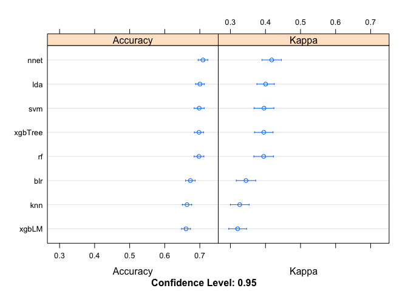

```r
# summarize accuracy of models
results <- resamples(list(lda=fit.lda, knn=fit.knn, svm=fit.svm, rf=fit.rf, blr=fit.blr, xgbTree=fit.xgbTree, xgbLM=fit.xgbLM,    nnet=fit.nnet))

dotplot(results)
```

It appears that the nnet model performed the best, at least on the training data. So from here on the neural network model will be the focus. One of the benefits of utilizing Caret to create models is that is that it tunes the model through the training phase. The parameters that were selected for the neural network can be seen below.

```r
print(fit.nnet)
```

```
## Neural Network
##
## 1048 samples
##   20 predictor
##    2 classes: '0', '1'
##
## No pre-processing
## Resampling: Cross-Validated (10 fold, repeated 5 times)
## Summary of sample sizes: 943, 943, 943, 944, 943, 944, ...
## Resampling results across tuning parameters:
##
##   size  decay  Accuracy   Kappa
##   1     0e+00  0.6990183  0.3978856
##   1     1e-04  0.6984451  0.3968017
##   1     1e-01  0.7089634  0.4177459
##   3     0e+00  0.6602839  0.3207143
##   3     1e-04  0.6612930  0.3223530
##   3     1e-01  0.6875952  0.3745876
##   5     0e+00  0.6343242  0.2687897
##   5     1e-04  0.6398681  0.2806304
##   5     1e-01  0.6803278  0.3603912
##
## Accuracy was used to select the optimal model using the largest value.
## The final values used for the model were size = 1 and decay = 0.1.
```

The final parameter values used in the neural network were size = 1 and decay = 0.1. The model will be tested before trying to manually tune the size and decay values to see if a greater performance could be reached.

```r
prednnet <- predict(fit.nnet, newdata = Test1, type = "raw")
confusionMatrix(prednnet, Test1$Results)
```

```
## Confusion Matrix and Statistics
##
##           Reference
## Prediction  0  1
##          0 31  7
##          1  7 22
##
##                Accuracy : 0.791
##                  95% CI : (0.6743, 0.8808)
##     No Information Rate : 0.5672
##     P-Value [Acc > NIR] : 0.000104
##
##                   Kappa : 0.5744
##
##  Mcnemar's Test P-Value : 1.000000
##
##             Sensitivity : 0.8158
##             Specificity : 0.7586
##          Pos Pred Value : 0.8158
##          Neg Pred Value : 0.7586
##              Prevalence : 0.5672
##          Detection Rate : 0.4627
##    Detection Prevalence : 0.5672
##       Balanced Accuracy : 0.7872
##
##        'Positive' Class : 0
##
```

The neural network model was able to correctly identify the outcomes of the 2019 March Madness tournament at a 79.1% accuracy. To see which features (or variables) that the model relied on the most, a basic plot can be created to show variable importance.

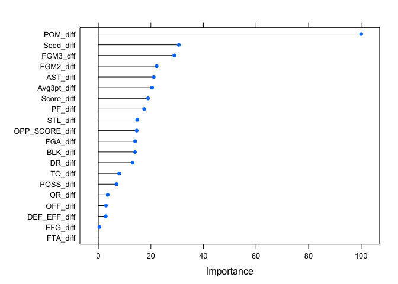

```r
Importance1 <- varImp(fit.nnet)
plot(Importance1)
```

| Based on the figure above, the neural network model deemed the Pomeroy Rankings to be the most important factor in determining who won each game. This is logical and should be the most important variable based on the results from the data visualization report, found [here](https://jeremykight.netlify.com/marchmadnessvisuals/). Really there are no surprises with how the neural network ranked the importance of the various features. However, the Effective Field Goal statistic is normally a stat that many individuals use when trying to pick winners but the neural network did not rely on it that much. The neural network prioritized 2 and 3 point field goals made over all other offensive statistics. From the defensive side of the ball, steals and blocks were the defensive stats relied on the most.

Next, the bottom 7 features that were not relied on as much will be taken out. Then the neural network will be trained again but on the small dataset.

```r
#Create new dataframe without the bottom seven features
Train2 <- RealGames %>%
  filter(Season <= 2018) %>%
  select(Results,POM_diff:Avg3pt_diff, OPP_SCORE_diff,
         BLK_diff:PF_diff)

#Make Results a factor
Train2$Results <- as.factor(Train2$Results)

#Neural Network nnet2
set.seed(3142)
fit2.nnet <- train(Results~., data=Train2, method="nnet", metric=metric, trControl=control)
```

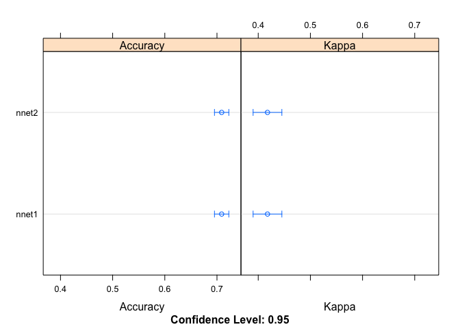

```r
#Compare accuracy of the Neural Networks
results2 <- resamples(list(nnet1=fit.nnet,nnet2=fit.nnet))

dotplot(results2)
```

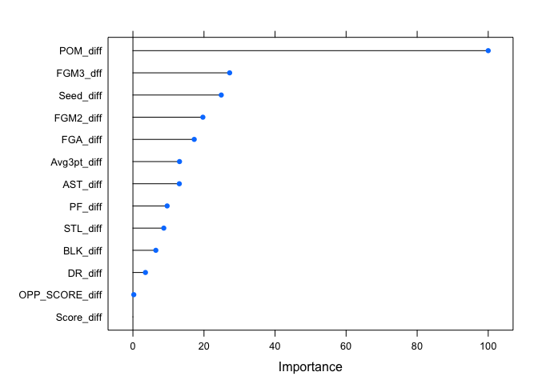

```r
Importance2 <- varImp(fit2.nnet)
plot(Importance2)
```

Just to see what would happen if the bottom three features (Score_diff, OPP_SCORE_diff, and DR_diff) were removed from the dataset, a third neural network can be trained. The same steps will be repeated as above.

```r
#Create new dataframe without the bottom three features
Train3 <- RealGames %>%
  filter(Season <= 2018) %>%
  select(Results,POM_diff:Seed_diff, FGA_diff:Avg3pt_diff,
         BLK_diff,AST_diff:PF_diff)

#Make Results a factor
Train3$Results <- as.factor(Train3$Results)

#Neural Network nnet3
set.seed(3142)
fit3.nnet <- train(Results~., data=Train3, method="nnet", metric=metric, trControl=control)
```

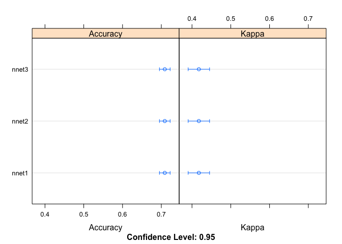

```r
#Compare accuracy of the Neural Networks
results3 <- resamples(list(nnet1=fit.nnet,nnet2=fit.nnet,nnet3=fit.nnet))

dotplot(results3)
```

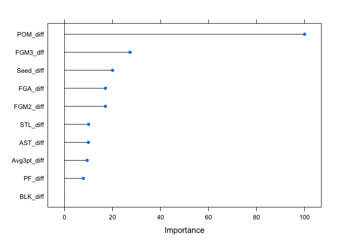

```r
Importance3 <- varImp(fit3.nnet)
plot(Importance3)
```

The process above could continue to be implemented, however, for this report no more variables will be eleminated for the risk of taking out a potential important factor. Now it is time to tune the neural network.

# Tuning Neural Network

The neural network that will be tuned is the third neural network created (nnet3). This neural network maintained a high accuracy with less features. To see the parameters that Caret set during training, run the following code.

```r
print(fit3.nnet)
```

```
## Neural Network
##
## 1048 samples
##   10 predictor
##    2 classes: '0', '1'
##
## No pre-processing
## Resampling: Cross-Validated (10 fold, repeated 5 times)
## Summary of sample sizes: 943, 943, 943, 944, 943, 944, ...
## Resampling results across tuning parameters:
##
##   size  decay  Accuracy   Kappa
##   1     0e+00  0.7102857  0.4204235
##   1     1e-04  0.7106667  0.4212246
##   1     1e-01  0.7129524  0.4256111
##   3     0e+00  0.6906612  0.3811915
##   3     1e-04  0.6879872  0.3755584
##   3     1e-01  0.7068608  0.4131938
##   5     0e+00  0.6629872  0.3256704
##   5     1e-04  0.6751905  0.3498147
##   5     1e-01  0.7026575  0.4048880
##
## Accuracy was used to select the optimal model using the largest value.
## The final values used for the model were size = 1 and decay = 0.1.
```

The values for size and decay will be taken into account when tuning the model manually. Above it can be seen that the optimal size was found to be 1, while the decay parameter was set to 0.1. To see if these are the best parameters for this neural network, an expanded tuning grid needs to be created.

```r
nnetgrid <- expand.grid(size = seq(from = 1, to = 5, by = 1),
                        decay = c(0.25,0.2,0.15, 0.1,0.075))
```

```r
set.seed(3142)
nnet_tune1 <- train(Results~.,
                   data=Train3,
                   method="nnet",
                   metric=metric,
                   trControl=control,
                   tuneGrid = nnetgrid)
```

```r
print(nnet_tune1)
```

```
## Neural Network
##
## 1048 samples
##   10 predictor
##    2 classes: '0', '1'
##
## No pre-processing
## Resampling: Cross-Validated (10 fold, repeated 5 times)
## Summary of sample sizes: 943, 943, 943, 944, 943, 944, ...
## Resampling results across tuning parameters:
##
##   size  decay  Accuracy   Kappa
##   1     0.075  0.7125696  0.4249327
##   1     0.100  0.7129524  0.4256200
##   1     0.150  0.7144908  0.4286659
```

[output cut: 25 more lines]

By setting the tuning grid to values close to the parameters that Caret prescribed, it was found that the optimal size and decay values are 1 and 0.2, respectively. While this is a minor adjustment, it should help the performance of the model on the testing set. Below, the performance of the new model on the testing set can be seen. Remember to take out the same features from the test dataset that was taken out of the training dataset for the third neural network model.

```r
Test2 <- Test1 %>%
  select(Results,POM_diff:Seed_diff, FGA_diff:Avg3pt_diff,
         BLK_diff,AST_diff:PF_diff)

prednnet2 <- predict(nnet_tune1, newdata = Test2, type = "raw")
confusionMatrix(prednnet2, Test2$Results)
```

```
## Confusion Matrix and Statistics
##
##           Reference
## Prediction  0  1
##          0 31  6
##          1  7 23
##
##                Accuracy : 0.806
##                  95% CI : (0.6911, 0.8924)
##     No Information Rate : 0.5672
##     P-Value [Acc > NIR] : 3.393e-05
##
##                   Kappa : 0.6064
##
##  Mcnemar's Test P-Value : 1
##
##             Sensitivity : 0.8158
##             Specificity : 0.7931
##          Pos Pred Value : 0.8378
##          Neg Pred Value : 0.7667
##              Prevalence : 0.5672
##          Detection Rate : 0.4627
##    Detection Prevalence : 0.5522
##       Balanced Accuracy : 0.8044
##
##        'Positive' Class : 0
##
```

Thus by adjusting the tuning parameters slightly, the accuracy of the model was increased to 80.6%. The difference the adjustment made appears to have effected the ability of the model to predict one more winning team correctly. Since this Kaggle competition is ranked on the logloss metric, the logloss should be calculated for the final model. To do this, first the probabilities of each decision should be calculated by the model.

```r
#Get the probalities for nnet_tune1
probnnet <- predict(nnet_tune1, newdata = Test2, type = "prob") %>%
  select(2)
```

Next, a new dataframe will be created from the “RealGames” dataframe created earlier. The dataframe will be filtered so that it only contains the games from the 2019 season. Then a new column will be added to display the results from the predictions of the final model. Lastly, the only columns that will be selected are “ID”, “Results”, and “Predicitons”. All the other columns will be discarded.

```r
EffectiveNNET <- RealGames %>%
  filter(Season == 2019) %>%
  mutate(Predictions = prednnet2) %>%
  select(ID,Results,Predictions)
```

Now that the new dataframe is created, it can be joined together with the probabilities calculated from the final model. This will be done by column binding “EffectiveNNET” by “probnnet”. To be clear, the column with the title “1” will be renamed to “Probability” to indicate the probability of the lower ID team beating the higher ID team.

```r
EffectiveNNET <- cbind(EffectiveNNET,probnnet) %>%
  rename(Probability = "1")
```

With the dataframe now containing everything that is needed, the logloss of the final model can now be calculated.

```r
#Logloss for NNET model
EffectiveNNET <- EffectiveNNET %>%
  summarise(LogLoss = logLoss(Results,Probability),
            Errors = sum(((Probability < 0.0)+(Probability > 1.0)+(is.na(Probability)))))

print(EffectiveNNET)
```

```
##     LogLoss Errors
## 1 0.4921599      0
```

The nature of the logloss metric is to penalized predictions that had very high probabilities in the wrong direction. In other words, logloss penalizing overly confident models. For example, if the final model predicted that Team A had a 90% chance of beating Team B. Then Team A loss, the logloss would be greater than if the model said Team A only had a 60% of winning. Now the winning logloss values in the Kaggle competition in 2019 was around 0.45 or 0.46. However, this is partially due to one popular strategy of manually overriding the probabilies of certain games. This is typically done in the first or second round of the tournament in games that the model is clearly over confident in. Since the overall objective was to create a model that could predict the outcomes of the March Madness Tournament with the greatest accuracy, the logloss metric was not a priority when constructing and tuning the model. If the goal is to do as well as possible in the Kaggle competition, then the logloss should be minimized as much as possible.

# Conclusion

The objective of this report was to create a machine learning model that could predict the winning teams in the March Madness basketball tournament by only looking at the teams’ statistics. Out of several machine learning models tested, the neural network model was found to be the model that performed the best. The most optimal parameters of the neural network were size = 1 and decay = 0.2. Overall, the created model was able to predict the outcomes 80.6% of the time with a logloss score of 0.492. This model will be adjusted and built upon for the 2021 March Madness Tournament since the 2020 March Madness Tournament was cancelled due to the Coronavirus outbreak.